# Pratiques des tests élémentaires

Stéphane Jaubert

1 novembre 2016

Download and Install https://cran.r-project.org/

Ce cours met en évidence le raisonnement commun à tous les tests statistiques utilisés dans des conditions variées. Sont abordées les comparaisons de moyennes, les données appariées et les statistiques de rang.

**1) Comparaison de la moyenne de deux échantillons**

**1.1 Le Test $t$ de comparaison de moyennes**

*Situation 1* - La variable mesurée est le poids du cerveau (en grammes) de 10 hommes et de 10 femmes (d’après R.J. Glastone, 1905).

La variable mesurée diffère-t-elle entre les deux sexes ?

```r
males <- c(1381,1349,1258,1248,1355,1335,1416,1475,1421,1383)
females <- c(1055,1305,1155,1120,1252,1208,1154,1197,1229,1212)
```

*Situation 2* - La variable mesurée est le temps de survie (en jours) de patients atteints d’un cancer et traités avec un médicament donné ([3], [1]). Cette variable dépend-t-elle du type de cancer ?

```r
estomac <- c(124,42,25,45,412,51,1112,46,103,876,146,340,396)
poumon <- c( 1235,24,1581,1166,40,727,3808,791,1804,3460,719)
```

$x_{1}, x_{2},...,x_{n}$ est un échantillon aléatoire simple. Chaque $x_{i}$ est la réalisation d’une variable aléatoire $X_{i}$ normale de moyenne $\mu_{1}$ et de variance $\sigma^{2}$. Les variables aléatoires $X_{i}$sont indépendantes entre elles, deux à deux. On parle de i.i.d.

$y_{1}, y_{2},...,y_{n}$ est un échantillon aléatoire simple. Chaque $y_{i}$ est la réalisation d’une variable aléatoire $Y_{i}$ normale de moyenne $\mu_{2}$ et de même variance $\sigma^{2}$. Les variables aléatoires $Y_{i}$sont indépendantes entre elles, deux à deux.

Les $X_{i}$ et les $Y_{i}$ sont indépendantes.

La différence des deux moyennes est une variable aléatoire $\bar{X}-\bar{Y}$.

L’espérance de la variable $\bar{X}-\bar{Y}$ est donc $E(\bar{X}-\bar{Y})=\mu_{1}-\mu_{2}$

$V(\bar{X}-\bar{Y})=V(\bar{X})+V(\bar{Y})=\frac{\sigma^{2}}{n_{1}}+\frac{\sigma^{2}}{n_{1}}$

La variable normalisée de la différence des moyennes est :

$Z=\frac{\left ( \bar{X}-\bar{Y} \right )-E\left ( \bar{X}-\bar{Y}\right )}{\sqrt{V\left ( \bar{X}-\bar{Y} \right )}}$

soit

$Z=\frac{\left ( \bar{X}-\bar{Y} \right )- \left ( \mu_{1}-\mu_{2} \right )}{\sqrt{\frac{\sigma^{2}}{n_{1}}+\frac{\sigma^{2}}{n_{1}}}}$

Sous l’hypothèse $H_{0}$, $\mu_{1}=\mu_{2,}$ donc la variable normalisée défini par : $\frac{\bar{X}-\bar{Y}}{\sqrt{\frac{\sigma^{2}}{n_{1}}+\frac{\sigma^{2}}{n_{1}}}}$

suit une loi $T$ de Student à $n_{1}+n_{2}-2$ degrés de liberté.

Elle prend la valeur particulière :

$t=\frac{\bar{x}-\bar{y}}{\sqrt{\frac{\sum_{i=1}^{n}\left (x_{i}-\bar{x} \right )^{2}+\sum_{i=1}^{n}\left (y_{i}-\bar{y} \right )^{2}}{n_{1}+n{2}-2}\left (\frac{1}{n_{1}}+\frac{1}{n_{2}} \right )}}$

où $\bar{x}=\frac{x_{1}+x_{2}+...+x_{n}}{n_{1}}$ et $\bar{y}=\frac{y_{1}+y_{2}+...+y_{n}}{n_{2}}$ sont les moyennes des échantillons .

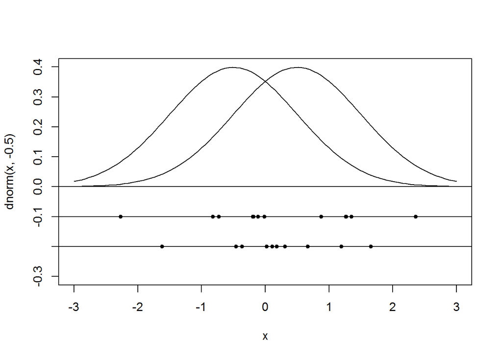

```r
x <- seq(-3, 3, le = 100)
plot(x, dnorm(x,-0.5), type = "l", ylim = c(-0.3,0.4))
lines(x, dnorm(x,0.5), type = "l")
y1 <- rnorm(12,-0.5)
y2 <- rnorm(10,0.5)
abline(h = c(0,-0.1,-0.2))
points (y1, rep(-0.1,12),pch=20)
points(y2, rep(-0.2,10),pch=20)
```

La loi de la différence des moyennes est :

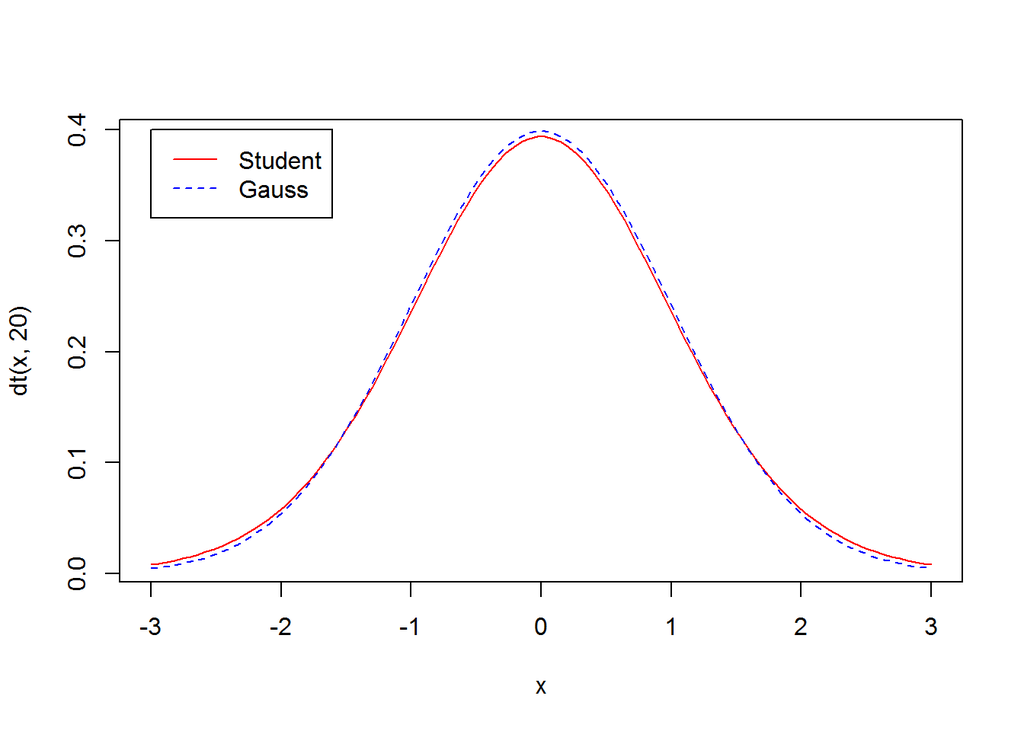

```r
plot(x, dt(x,20), type="l", col="red")
lines(x, dnorm(x), type="l", col="blue", lty=2)
legend(-3,0.4,lty=1:2, col=c("red","blue"),legend=c("Student","Gauss"))
```

Si l’alternative est $\mu_{1}>\mu_{2}$ , les valeurs positives de $\bar{x}_{1}-\bar{x}_{2}$ sont attendues et on rejette l’hypothèese avec le risque $P(T>t)$. Si l’alternative est $\mu_{1}<\mu_{2}$, les valeurs négatives de $\bar{x}_{1}-\bar{x}_{2}$ sont attendues et on rejette l’hypothèse avec le risque $P(T < t)$. Si l’alternative est $\mu_{1} \neq \mu_{2}$, les valeurs positives ou négatives de $\bar{x}_{1}-\bar{x}_{2}$2 sont attendues et on rejette l’hypothèse avec le risque $2P(T >|t|)$.

Appliquée à la situation 1, cette procédure donne :

```r
m1<-mean(males)
m2<-mean(females)
```

```r
n1<-length(males)
n2<-length(females)
varcom<-((n1-1)*var(males)+(n2-1)*var(females))/(n1+n2-2)
```

```r
t<-(m1-m2)/sqrt(varcom*(1/n1+1/n2))
```

La moyenne du poids du cerveau chez les hommes est de 1362.1g. La moyenne du poids du cerveau chez les femmes est de 1188.7g. La différence normalisée est de 5.4894 pour 18 degrés de liberté. La probabilité d’avoir une différence inférieure à -5.4894 ou supérieure à 5.4894 est :

```r
if (t<0) pt(t,18) else (1-pt(t,18))
```

```
## [1] 1.629934e-05
```

```r
pcrit<-if (t<0) pt(t,18) else (1-pt(t,18))
2*pcrit
```

```
## [1] 3.259868e-05
```

La probabilité de la zone de rejet est de 0 et l’hypothèse nulle est rejetée.

Ces résultats se retrouvent sous par la formulation suivante :

```r
tt0 <- t.test(males, females, var.eq = T)
tt0
```

```
##
##  Two Sample t-test
##
## data:  males and females
## t = 5.4894, df = 18, p-value = 3.26e-05
## alternative hypothesis: true difference in means is not equal to 0
## 95 percent confidence interval:
##  107.0358 239.7642
## sample estimates:
## mean of x mean of y
##    1362.1    1188.7
```

Appliquée à la situation 2, cette procédure donne :

```r
tt0 <- t.test(estomac, poumon, var.eq = T)
tt0
```

```
##
##  Two Sample t-test
##
## data:  estomac and poumon
## t = -3.1013, df = 22, p-value = 0.005209
## alternative hypothesis: true difference in means is not equal to 0
## 95 percent confidence interval:
##  -1852.1210  -367.6971
## sample estimates:
## mean of x mean of y
##   286.000  1395.909
```

**1.2 Le test de Wilcoxon (Mann-Whitney)**

On pourrait croire que les deux situations précédentes sont identiques. Il n’en est rien :

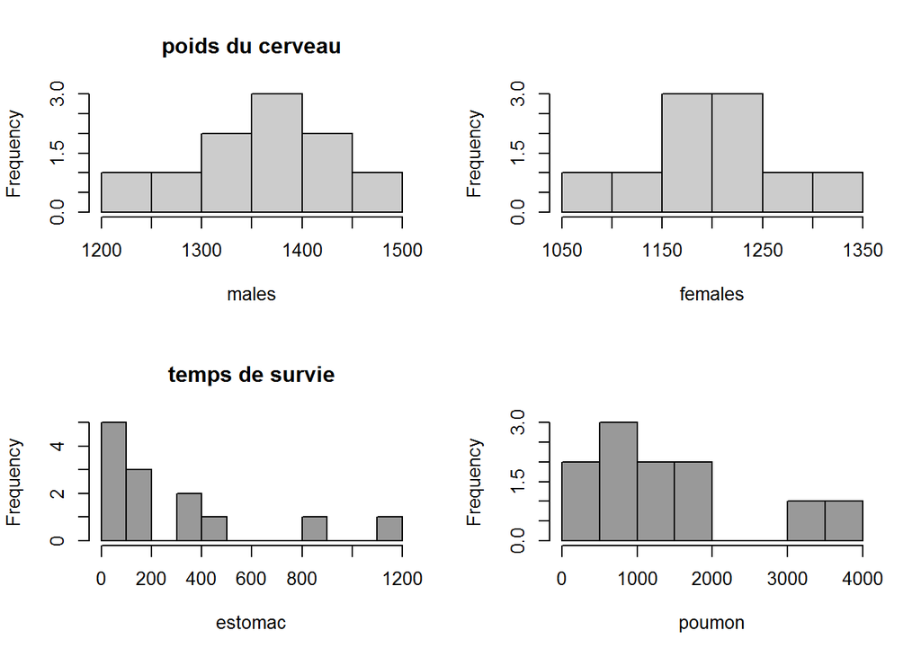

```r
par(mfrow=c(2,2))
hist(males,nclass = 8, col=grey(0.8), main="poids du cerveau", xlab="males")
hist(females,nclass = 8, col=grey(0.8), main="", xlab="females")
hist(estomac, nclass = 8, col=grey(0.6), main="temps de survie", xlab="estomac")
hist(poumon, nclass = 8, col=grey(0.6), main="", xlab="poumon")
```

```r
par(mfrow=c(1,1))
```

La première distribution est relativement symétrique, la deuxième ne l’est pas du tout. Dans l’ensemble des hypothèses nécessaires au test de Student, celui de la normalité peut être globalement invalide. Rejeter l’hypothèse d’égalité des moyennes n’a pas de sens. Il existe des stratégies utilisables quelle que soit la forme de variation des données. On les appelle *libre de distribution*. Le plus simple est le test de Wilcoxon (on dit aussi Mann-Whitney). Le raisonnement est le suivant. On reunit les deux échantillons :

```r
n1 <- length(estomac)
n1
```

```
## [1] 13
```

```r
n2 <- length(poumon)
survie <- c(estomac, poumon)
survie
```

```
##  [1]  124   42   25   45  412   51 1112   46  103  876  146  340  396 1235
## [15]   24 1581 1166   40  727 3808  791 1804 3460  719
```

Le rang d’une donnée est le numéro d’ordre de cette donnée quand elles sont rangées par ordre croissant.

```r
which.min(survie)
```

```
## [1] 15
```

```r
survie[which.min(survie)]
```

```
## [1] 24
```

```r
which.max(survie)
```

```
## [1] 20
```

```r
survie[which.max(survie)]
```

```
## [1] 3808
```

La plus petite donnée est située en quinzième position. Elle vaut 24. Son rang est 1. La plus grande donnée est située en vingtième position. Elle vaut 3808. Son rang est 24 :

```r
rtot <- rank(survie)
rtot
```

```
##  [1]  9  4  2  5 13  7 18  6  8 17 10 11 12 20  1 21 19  3 15 24 16 22 23
## [24] 14
```

Les individus du premier groupe ont les rangs :

```r
r1 <- rtot[1:n1]
r1
```

```
##  [1]  9  4  2  5 13  7 18  6  8 17 10 11 12
```

Les individus du deuxième groupe ont les rangs :

```r
r2 <- rtot[(n1 + 1):(n1 + n2)]
r2
```

```
##  [1] 20  1 21 19  3 15 24 16 22 23 14
```

Si les individus des deux groupes proviennent de la même population, les rangs des individus du premier groupe sont tirés au hasard dans l’ensemble des 24 premiers entiers. Si les moyennes des deux échantillons ne sont pas égales, les rangs du premier groupe auront tendance à être trop grands ou trop petits. La statistique utilisée est **la somme des rangs**. Evidemment, le raisonnement est symétrique sur les deux groupes. Par convention, on raisonne sur le premier échantillon. On appelle $m$ l’effectif de cet echantillon et $n$l’effectif total. L’effectif du second groupe est par déduction $n-m$.

Les valeurs $x_{i}$ des deux échantillons réunis sont classées par ordre croissant $_{(i)}$

La statistique du test est la somme des rangs $SR$ du premier groupe et est appelée statistique de Wilcoxon.

$SR=\sum_{i=1}^{m}R_{i}$ où les $R_{i}$ suivent la loi uniforme (sous réserve qu’il n’y ait pas d’ex-aequo, pour simplifier la démonstration), d’espérance $E(R_{i})=\frac{n+1}{2}$ et de variance $V(R_{i})=\frac{n^{2}-1}{12}$

On a :

$E(SR)=E(\sum_{i=1}^{m}R_{i})=\sum_{i}^{m}E(R_{i})=\frac{m(n+1)}{2}$

$V(SR)=V(\sum_{i=1}^{m}R_{i})=\sum_{i=1}^{m}V(R_{i})+\sum_{i\neq j}^{}cov(R_{i},R_{j})$

La statistique de Wilcoxon SR suit approximativement une loi normale de moyenne $E(SR)$ et variance $V (SR)$ ($m \geq 10$ et $n-m \geq 10$. Il existe des tables donnant les seuils de signification pour les petits effectifs et les bons logiciels donnent la loi exacte connue s’il n’y a pas d’ex aequo.

Souvent, les logiciels utilisent la statistique $U$ de Mann-Whitney :

$U=SR-\frac{m(m+1)}{2}$

D’après ce qui précède et sous les mêmes conditions, celle-ci suit approximativement une loi normale de moyenne et variance :

$E(U)=\frac{m(n-m)}{2}$ ; $V(U)=\frac{m(n-m)(n+1)}{12}$

**A. Calculs à la main sous**

*Statistique de Wilcoxon*

```r
(sr<-sum(r1))
```

```
## [1] 122
```

```r
(esr<- n1*(n1+n2+1)/2)
```

```
## [1] 162.5
```

```r
(vsr<- n1*n2*(n1+n2+1)/12)
```

```
## [1] 297.9167
```

```r
(t0<- (sr-esr)/sqrt(vsr))
```

```
## [1] -2.34643
```

```r
2*pnorm(t0)
```

```
## [1] 0.01895422
```

*Statistique de Mann-Whitney*

```r
(u<- sr-(n1*(n1+1))/2)
```

```
## [1] 31
```

```r
(eu<- n1*n2/2)
```

```
## [1] 71.5
```

```r
(vu<- (n1*n2*(n1+n2+1))/12)
```

```
## [1] 297.9167
```

```r
(t1<-(u-eu)/sqrt(vu))
```

```
## [1] -2.34643
```

```r
2*pnorm(t1)
```

```
## [1] 0.01895422
```

**B. La procédure sous**

```r
wilcox.test(estomac,poumon,exact = F,correct = F)
```

```
##
##  Wilcoxon rank sum test
##
## data:  estomac and poumon
## W = 31, p-value = 0.01895
## alternative hypothesis: true location shift is not equal to 0
```

Le logiciel donne également la valeur exacte :

```r
wilcox.test(estomac, poumon, exact = T)
```

```
##
##  Wilcoxon rank sum test
##
## data:  estomac and poumon
## W = 31, p-value = 0.01836
## alternative hypothesis: true location shift is not equal to 0
```

L’approximation est très justifiée. On refera les calculs pour l’autre exemple sur le poids du cerveau chez l’homme.

```r
n1 <- length(males)
n2 <- length(females)
longueur <- c(males, females)
rtot <- rank(longueur)
rtot
```

```
##  [1] 16 14 11  9 15 13 18 20 19 17  1 12  4  2 10  6  3  5  8  7
```

```r
r1 <- rtot[1:n1]
r1
```

```
##  [1] 16 14 11  9 15 13 18 20 19 17
```

```r
sr <- sum(r1)
u <- sr - (n1 * (n1+1))/2
eu <- (n1 * n2)/2
vu <- (n1 * n2 * (n1 + n2 + 1))/12
t1 <- (u - eu)/sqrt(vu)
2 * (1 - pnorm(t1))
```

```
## [1] 0.0003810585
```

```r
wilcox.test(males, females)
```

```
##
##  Wilcoxon rank sum test
##
## data:  males and females
## W = 97, p-value = 7.578e-05
## alternative hypothesis: true location shift is not equal to 0
```

Le logiciel (professionnel) utilise une correction pour les exaequo et une correction supplémentaire de continuité. Ce sont des raffinements. On s’en tiendra à la version simple.

Dans la situation 1 (normalité acceptable pour des données morphométriques), le test t et le test de Wilcoxon donnent tous deux un rejet à 0.000. Dans la situation 2 (normalité non acceptable pour des données de temps d’attente), le test t donne un rejet à 0.005 et le test de Wilcoxon un rejet à 0.02. Le test non paramétrique est utilisable dans tous les cas.

**2. Comparaison de $s$ échantillons**

**2.1 Test de Kruskal et Wallis**

Dans une bibliothéque, il y a des livres de voyage, des ouvrages généraux et des livres de statistiques. On a trois échantillons.

1. Le premier est celui des livres de voyage. Ils ont respectivement 93, 98,216, 249, 301, 319, 731 et 910 pages.
2. Le second est celui des livres généraux. Ils ont 29, 39, 60, 78, 82, 112, 125,170, 192, 224, 263, 275, 276, 286, 369 et 756 pages.
3. Le troisième est celui des livres de statistiques. Ils ont 126, 142, 156, 228,245, 246, 370, 419, 433, 454, 478 et 503 pages.

La question est “Ces echantillons proviennent-ils d’une même population ou au contraire un au moins des trois échantillons présentent une originalité en ce qui concerne la taille moyenne ?”.

```r
livre <- c(93,98,216,249,301,319,731,910,29,39,60,78,82,112,125,170,192,224,263,275,276,286,369,756,126,142,156,228,245,246,370,419,433,454,478,503)
(group <- factor(rep(1:3,c(8,16,12))))
```

```
##  [1] 1 1 1 1 1 1 1 1 2 2 2 2 2 2 2 2 2 2 2 2 2 2 2 2 3 3 3 3 3 3 3 3 3 3 3
## [36] 3
## Levels: 1 2 3
```

Le “bon” dessin est :

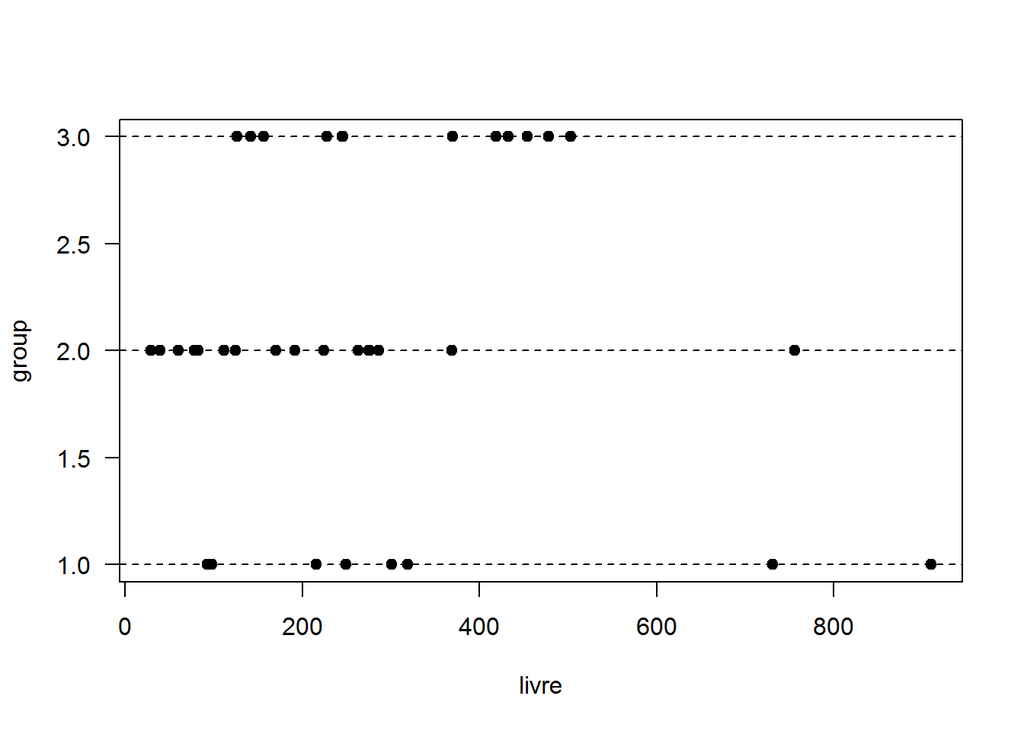

```r
plot(livre, group, pch=20, las=1, cex=1.5)
abline(h=1, lty=2)
abline(h=2, lty=2)
abline(h=3, lty=2)
```

Les données complètes sont rangées :

```r
rank(livre)
```

```
##  [1]  6  7 15 20 25 26 34 36  1  2  3  4  5  8  9 13 14 16 21 22 23 24 27
## [24] 35 10 11 12 17 18 19 28 29 30 31 32 33
```

```r
rank(livre)[group==1]
```

```
## [1]  6  7 15 20 25 26 34 36
```

```r
rank(livre)[group==2]
```

```
##  [1]  1  2  3  4  5  8  9 13 14 16 21 22 23 24 27 35
```

```r
rank(livre)[group==3]
```

```
##  [1] 10 11 12 17 18 19 28 29 30 31 32 33
```

Si n est le nombre total d’échantillons, la somme des rangs vaut toujours :

$SR_{tot}=1+...+n=\frac{n(n+1)}{2}$

```r
sum(rank(livre))
```

```
## [1] 666
```

```r
36*37/2
```

```
## [1] 666
```

Si n est le nombre total d’échantillons, la somme des carrés des rangs vaut toujours :

$SCR_{tot}=1²+2²+...+n²=\frac{n(n+1)(2n+1)}{6}$

```r
36*37*(2*36+1)/6
```

```
## [1] 16206
```

Si $SR_{j}$ est la somme des rangs de l’échantillon $j$ , la variable $T$ définie par :

$T=\frac{12\sum_{j=1}^{s}\frac{SR_{j}^{2}}{n_{j}}}{n(n+1)}-3(n+1)$

suit une loi du $\chi^{2}$ à ($s-1$) degrés de liberté. Cela suffit pour exécuter le test de Kruskal-Wallis.

```r
s1 <- sum(rank(livre)[group==1])
s2 <- sum(rank(livre)[group==2])
s3 <- sum(rank(livre)[group==3])
c(s1,s2,s3)
```

```
## [1] 169 227 270
```

```r
(s1^2/length(s1))+(s2^2/length(s2))+(s3^2/length(s3))
```

```
## [1] 152990
```

```r
(s1^2/length(s1))+(s2^2/length(s2))+(s3^2/length(s3)) -> partiel
partiel*12/(36*37)-3*37
```

[output not shown]

La loi du $\chi^{2}$ à $m$ ddl est définie dans la théorie comme celle de la somme de $m$ carrés de lois normales indépendantes. Les densités de probabilité ont des formes typiques :

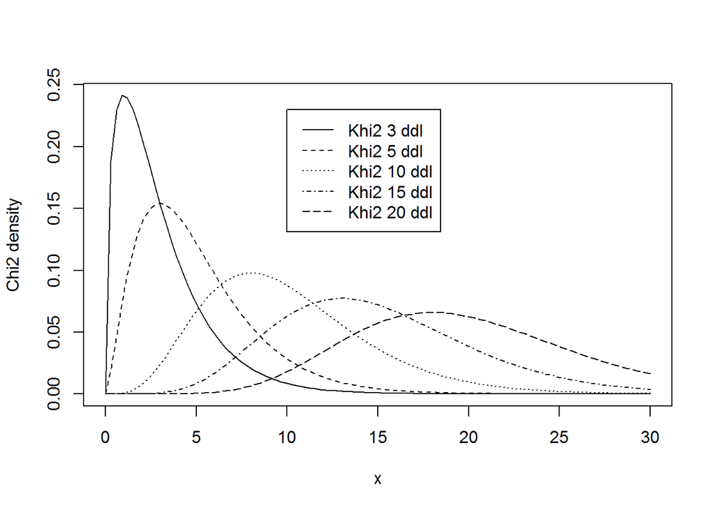

```r
x0 <- seq(0,30,le=100)
y1 <- dchisq(x0,3)
y2 <- dchisq(x0,5)
y3 <- dchisq(x0,10)
y4 <- dchisq(x0,15)
y5 <- dchisq(x0,20)
plot(x0, y1, type="n", xlab="x", ylab="Chi2 density")
lines(x0, y1, lty = 1)
lines(x0, y2, lty = 2)
lines(x0, y3, lty = 3)
lines(x0, y4, lty = 4)
lines(x0, y5, lty = 5)
l0 = c("Khi2 3 ddl","Khi2 5 ddl","Khi2 10 ddl","Khi2 15 ddl","Khi2 20 ddl")
legend(10,0.23,l0, lty=1:5)
```

La procédure du test sous est donnée par :

```r
kruskal.test(livre~group)
```

```
##
##  Kruskal-Wallis rank sum test
##
## data:  livre by group
## Kruskal-Wallis chi-squared = 4.9071, df = 2, p-value = 0.08599
```

**2.2 Comparer les variances**

Dans trois groupes de TD, les notes de contrôle continu sont :

```r
x1 <- c(14.9,12.0,9.5,7.3,8.4,9.8,11.0,13.8,14.3,5.0,4.4,14.3,13.7,18.0,12.4)
x2 <- c(10.9,10.1,10.0,12.2,10.0,11.1,10.3,9.5,9.6,10.0,10.9,11.2)
x3 <- c(13.0,12.1,8.7,10.9,12.7,9.5,10.5,12.2,16.0,10.3,9.6,10.9,7.3,9.8)
```

Les enseignants se réunissent pour vérifier qu’il n’y a pas de différences sensibles entre leur notation.

```r
mean(x1)
```

```
## [1] 11.25333
```

```r
mean(x2)
```

```
## [1] 10.48333
```

```r
mean(x3)
```

```
## [1] 10.96429
```

```r
gtd <- rep(1:3, c(15,12,14))
note <- c(x1, x2, x3)
kruskal.test(note, gtd)
```

```
##
##  Kruskal-Wallis rank sum test
##
## data:  note and gtd
## Kruskal-Wallis chi-squared = 0.72041, df = 2, p-value = 0.6975
```

Tout va bien. “Pas du tout” dit le représentant des étudiants. Faites donc le bon dessin :

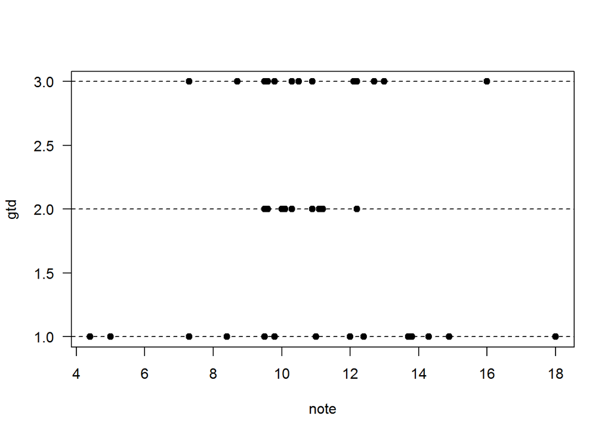

```r
plot(note, gtd, pch=20, las=1, cex=1.5)
abline(h=1, lty=2)
abline(h=2, lty=2)
abline(h=3, lty=2)
```

-Vous voyez bien que les amplitudes de notation diffèrent grandement entre les groupes. -Mais non, c’est le hasard. -Impossible ! -Alors, prouvez le !

```r
median(note)
```

```
## [1] 10.9
```

```r
kruskal.test(abs(note - median(note))~gtd)
```

```
##
##  Kruskal-Wallis rank sum test
##
## data:  abs(note - median(note)) by gtd
## Kruskal-Wallis chi-squared = 14.32, df = 2, p-value = 0.0007772
```

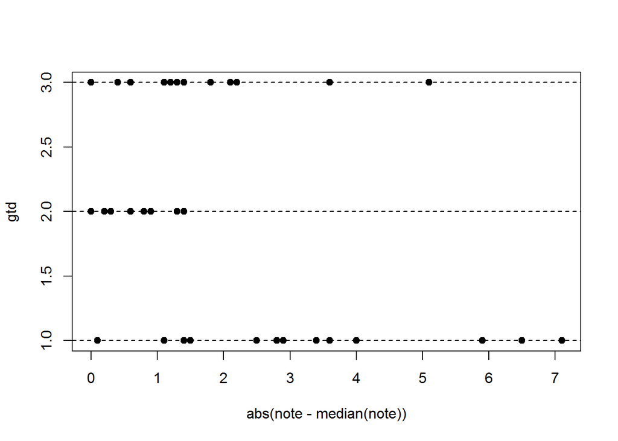

```r
plot(abs(note - median(note)), gtd, pch=20, cex = 1.5)
abline(h=1, lty=2)
abline(h=2, lty=2)
abline(h=3, lty=2)
```

Moralité : un test peut en cacher un autre.